# Project 2

Mehal Agrawal

2023-11-06

# **1) Introduction**

This dataset analyzes the airplane landings at SFO International Airport. The data has been obtained from DataSF, a website that tracks different types of data in San Francisco. This data is publicly available to help enhance decision making. The dataset was received from [here](https://data.sfgov.org/Transportation/Air-Traffic-Landings-Statistics/fpux-q53t). I picked this dataset because I love to travel and have been to SFO many times as it is my local airport. I was interested in analyzing the air traffic at SFO in relation to where the flight is departing from, the total weight of the flight, the type of aircraft, and the manufacturer of the aircraft.

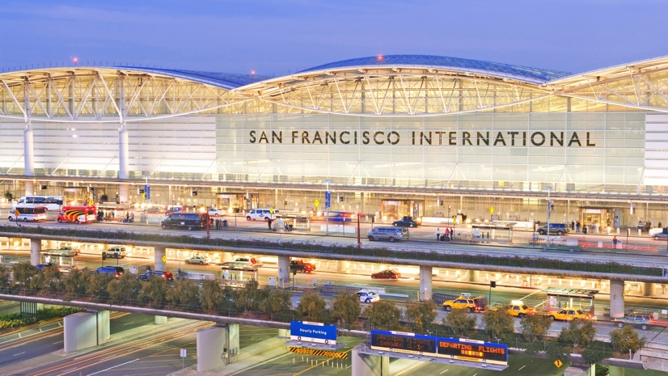

Bills, Terry. “San Francisco Airport’s Dynamic Twin Has Transformed Operations.” Esri, 21 Oct. 2021, esri.com/about/newsroom/blog/san-francisco-airport-bim-gis-processes/. Accessed 07 Nov. 2023.

# **2) Data Preparation**

# **3) Variable Descriptions**

| Name | Type | Description |
| --- | --- | --- |
| Activity_Period | Numeric | Year and month at which the landing activity took place |
| Operating_Airline | Character | Operator name of the aircraft with passenger, cargo, or landing activity |
| Operating_Airline | Character | International Air Transport Association two-letter designation for the Operating Airline |
| Published_Airline | Character | Name of Airline that issues ticket and books revenue for aircraft |
| Published_Airline_IATA_Code | Character | International Air Transport Association two-letter designation for the Publsihed Airline |
| GEO_Summary | Character | Designates whehter the passenger, cargo, or landings activity in relation to SFO arrived from a domestic or international location |
| GEO_Region | Character | Detailed breakdown of Geo Summary designating the region from which the aircraft departed from |
| Landing_Aircraft_Type | Character | Type of aircraft landed (freighters, passenger, or combi) |
| Aircraft_Body_Type | Character | Determines whether aircraft is a wide body, narrowbody, regional, or prpeller operated aircraft |
| Aircraft_Manufacturer | Character | Manufacturer name of aircraft |
| Aircraft_Model | Character | Model of aircraft designated by manufacturer |
| Aircraft_Version | Character | Variation of Aircraft Model (dash number) used to segregate uniqeu version of same model |
| Landing_Count | Numeric | Number of aircaft landings |
| Total_Landed_Weight | Numeric | Total Landed Weight |
| Continent | Character | Continent from which aircraft departed from |
| Month | Character | Coresponding Month for Activity |
| Total_Landed_Weight_In_Millions | Numeric | Total Landed Weight In Millions |

# **4) Univariate Analyses**

### Graph 1

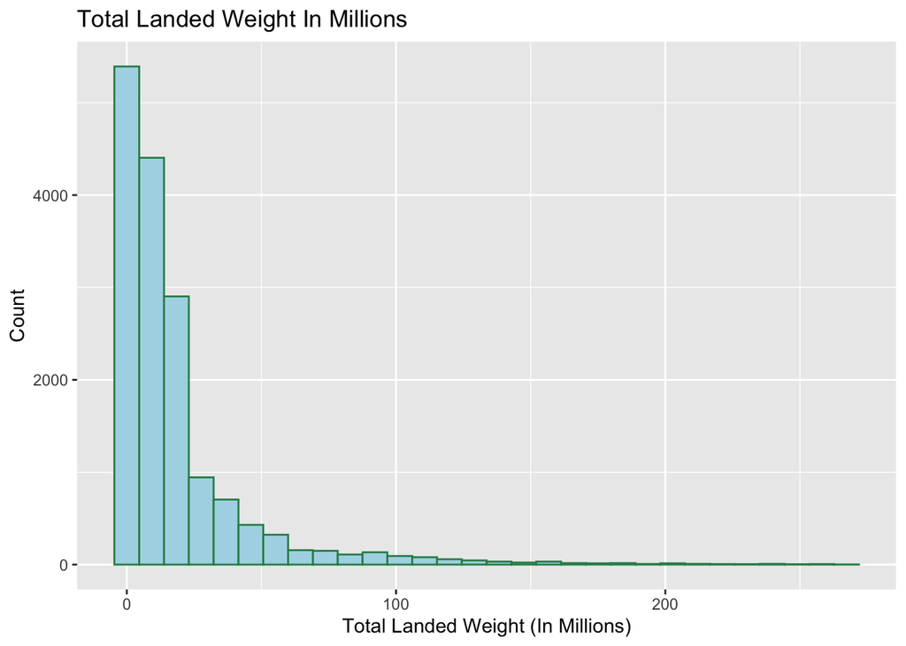

This graph displayed a histogram of the Total Landed Weight In Millions for each plane type. The histogram is skewed right with a mean of 18.4. The maximum total weight landed is 267.3 and the minimum total landed weight in millions is 0.01.

### Graph 2

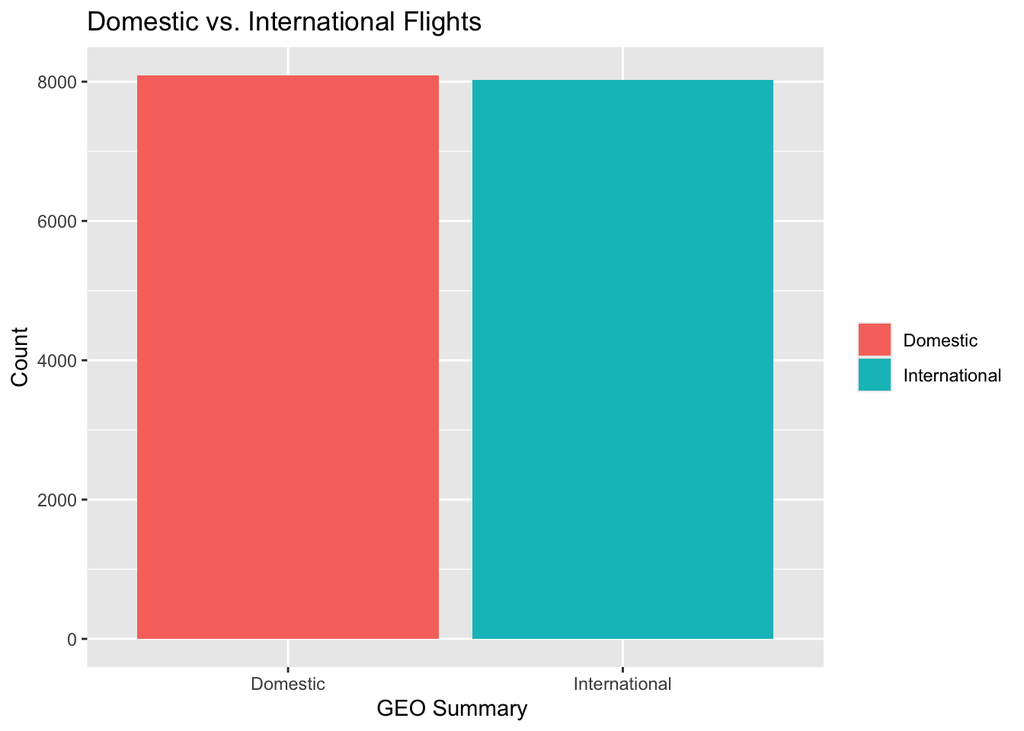

This bar graph shows the number of planes that arrived from a domestic location and the number of planes that arrived from an international location. 8092 arrived from a domestic location or 50.2% of planes. 8023 or 49.8% of planes arrived from an international location.

### Graph 3

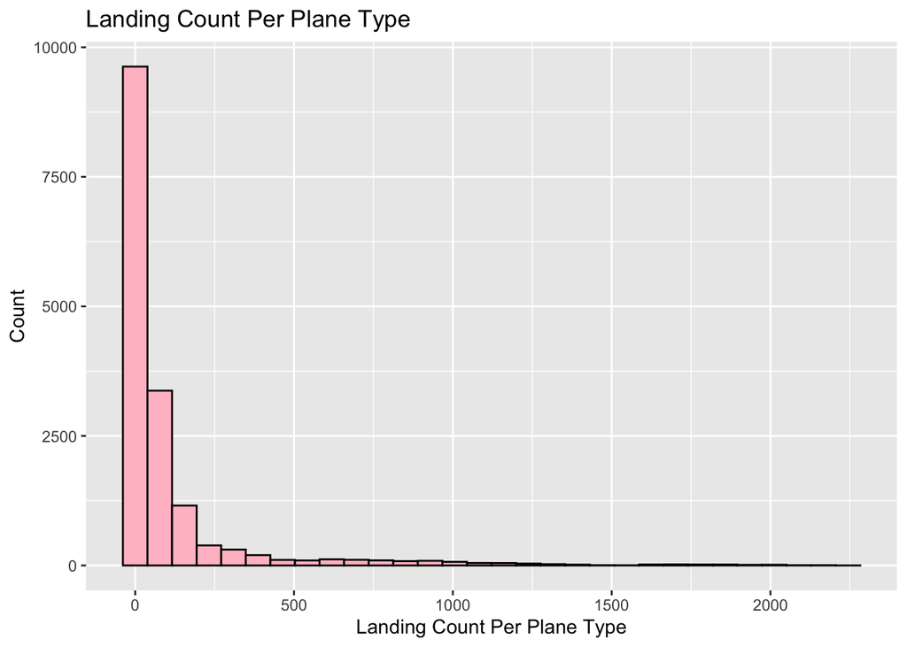

This histogram shows the landing count of each plane type at SFO Airport. It is skewed right with a mean of 112.55. The maximum number of times a plane type landed is 2245.

### Graph 4

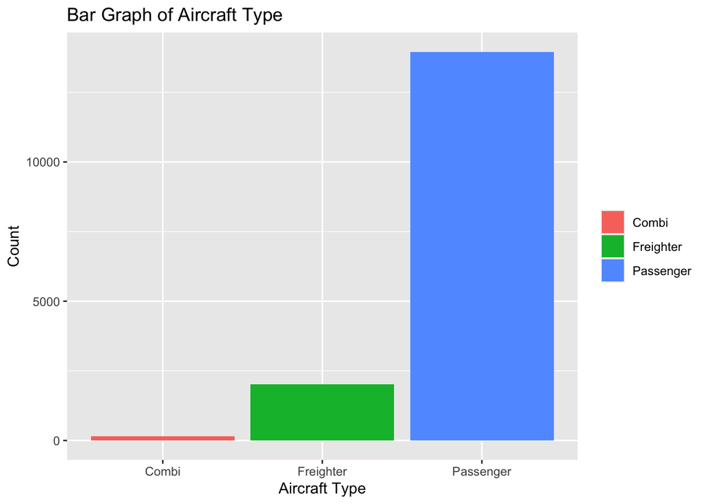

This bar graph shows the number of planes that are Combi, Freighter, or Passenger planes. As seen by the graph majority of the planes that landed are passenger aircrafts. 142 are Combi or 0.9% of planes. 2021 or 12.5% of planes are freighter. 13952 are Passenger or 86.6% of planes.

# **5) Multivariate Analyses**

### Graph 1

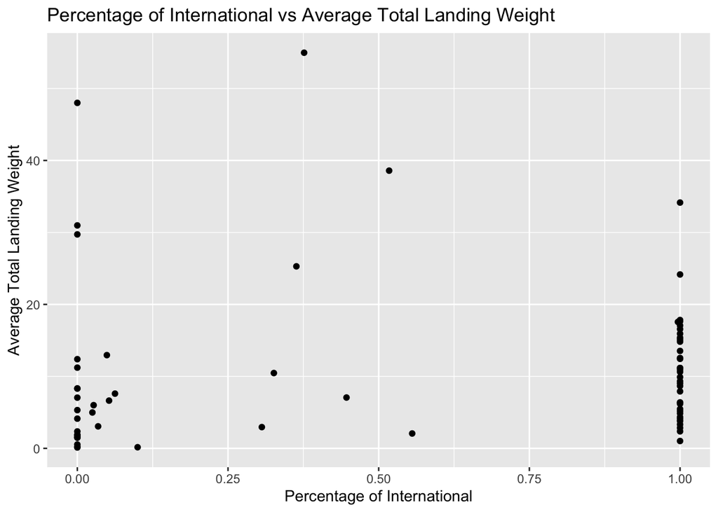

This plot graphs the proportion of each airplane type that is international and its average total weight. The correlation coefficient is 0.06. This means that there is a weak relationship between the proportion of international planes for each airline and its average weight.

### Graph 2

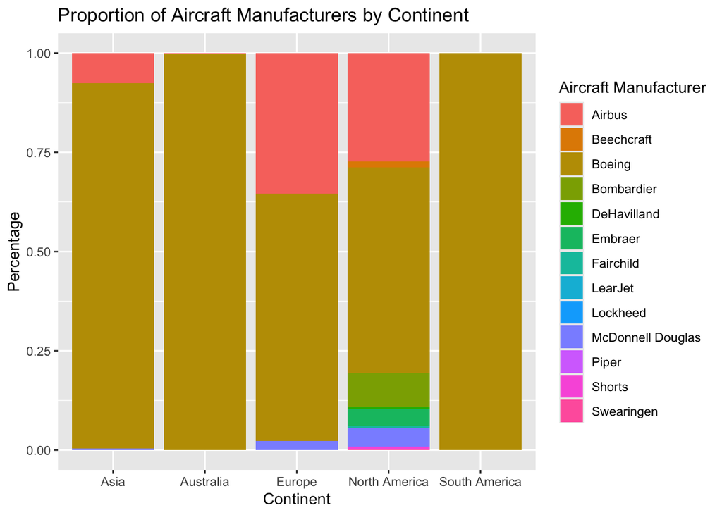

Proportion of Aircraft Manufacturers by Continent

|  | Airbus | Beechcraft | Boeing | Bombardier | DeHavilland | Embraer | Fairchild | LearJet | Lockheed | McDonnell Douglas | Piper | Shorts | Swearingen |
| --- | --- | --- | --- | --- | --- | --- | --- | --- | --- | --- | --- | --- | --- |
| Asia | 0.076 | 0.000 | 0.921 | 0.000 | 0.000 | 0.000 | 0.000 | 0 | 0 | 0.003 | 0.000 | 0.000 | 0.000 |
| Australia | 0.002 | 0.000 | 0.998 | 0.000 | 0.000 | 0.000 | 0.000 | 0 | 0 | 0.000 | 0.000 | 0.000 | 0.000 |
| Europe | 0.354 | 0.000 | 0.623 | 0.000 | 0.000 | 0.000 | 0.000 | 0 | 0 | 0.023 | 0.000 | 0.000 | 0.000 |
| North America | 0.273 | 0.015 | 0.519 | 0.086 | 0.004 | 0.043 | 0.005 | 0 | 0 | 0.047 | 0.001 | 0.006 | 0.001 |
| South America | 0.000 | 0.000 | 1.000 | 0.000 | 0.000 | 0.000 | 0.000 | 0 | 0 | 0.000 | 0.000 | 0.000 | 0.000 |

### Graph 3

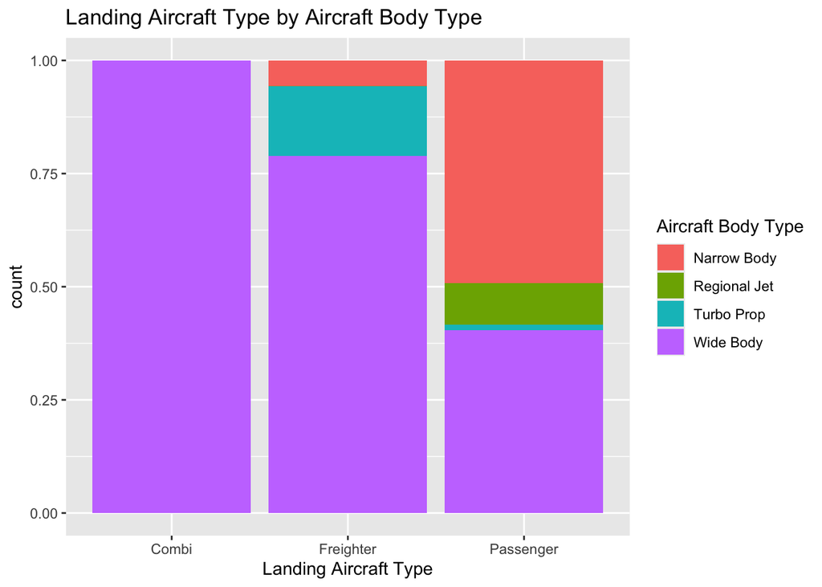

Proportion of Aircraft Body Types by Landing Aircraft Type

|  | Narrow Body | Regional Jet | Turbo Prop | Wide Body |
| --- | --- | --- | --- | --- |
| Combi | 0.000 | 0.000 | 0.000 | 1.000 |
| Freighter | 0.056 | 0.000 | 0.154 | 0.789 |
| Passenger | 0.492 | 0.092 | 0.011 | 0.404 |

This graph is a contingency bar chart. It uses the variable “Landing_Aircraft_Type” and graphs the aircraft type while filling the bar with the percentage of body type. By looking at the bar graph, all of the combi planes have wide body types. Passenger has the most variation in air craft body types with all four types being represented. However, according to the table almost 50% of the passanger planes have narrow body types. Turbo Prop only makes up a mere 1% of passenger planes.

### Graph 4

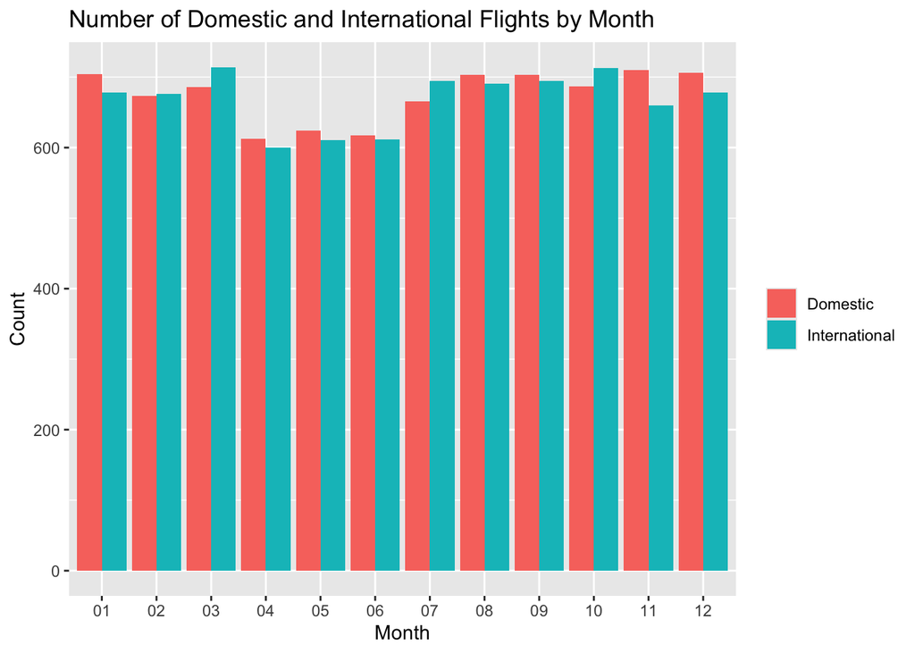

Percentage of International or Domestic Flights each month

|  | Domestic | International |
| --- | --- | --- |
| 01 | 0.509 | 0.491 |
| 02 | 0.499 | 0.501 |
| 03 | 0.490 | 0.510 |
| 04 | 0.505 | 0.495 |
| 05 | 0.505 | 0.495 |
| 06 | 0.502 | 0.498 |
| 07 | 0.489 | 0.511 |
| 08 | 0.504 | 0.496 |
| 09 | 0.503 | 0.497 |
| 10 | 0.491 | 0.509 |
| 11 | 0.518 | 0.482 |
| 12 | 0.510 | 0.490 |

This bar graph displays the number of flights that came from an international or domesic location every month. The number of flights departing from a domestic location or international location is mostly even year around. However, during July there 51.1% of the flight are international and 48.9% are domestic. This might be because many people travel internationally during the summer. In addition, during November 51.8% of the flightes became domestic and 48.2% were international. This could be because many people fly to be with their family during Thanksgiving. However, this is only true for the Uniteed States so that’s why there is an influx in domestic flights and not international flights.

# **6) Reproducibility**

To ensure reproducibility in my code I made sure that the csv file and picture were both uploaded to github. I made sure to comment my code so that it would easily traceable. I also tried to use packages that users would already have downloaded on their systems so that they would not have to install packages. I made my code sequential so that it would be easy to understand.

# **7) Choice Elements**

The first choice element I included was formatting a string variable. All of my variable names included spaces in them and in order to reference them easily throughout the code, I changed the variable names to have underscores instead of spaces. I also created 3 new variables of interest. This was the Total Weight of the aircraft in millions, continent, and month. I created the first one because the weight values when recorded raw were ver large and would become hard to handle. I created a continent variable because I wanted to generalize the region variable further while analyzing the location an aircraft departed from. The last variable helped me analyze the relationship between domestic and international flights in relation to the month. I used string formatting here too. These elements showed up in the second section of my report. The third element I used was a loop. This showed up while I was creating my continent variable as well as when I was trying to find the percentage of international flights for each airline. I used if statements also while creating my continent variable. Finally, I used inline code throughout my report while describing statistics of graphs.

# **8) Conclusion**

For Univariate graphs I graphed the Total Landed Weight in Millions, number of flights that were domestic or international, landing count, and the aircraft type. I expected the Total Landed Weight graph to be skewed right because most planes will have weights around the same amount and then it will taper off. I expected the amount of planes coming from a domestic or international location to be around the same because San Francisco is an airport that supports both international and domestic landings. For landing count per plane type the graph was skewed right. Finally, I expected the amount of passenger planes to be the most common aircraft type landing at SFO because it mostly supports passengers.

For the Multivariate graphs I expected that there would be a positive correlation between the percentage of international planes and the average total landing weight. However, the graph had a correlation coefficient of 0.06 signifyng a very weak relationship. In the second graph the bar having planes departing from a region in North America had the most variation in aircraft manufacturers. I found it suprising that 100% of South America’s aircrafts were manufactured by Boeing. I found it surprising that freighter planes had a variety in aircraft body types. I expectd it to be mostly wide body planes as they would be able to carry the most cargo. Finally, I expected the amount of international flights to be drastically more during the summer months because people travel more. However, the difference between the number of domestic and international flights was not as drastic as I expected. However the influx of domestic flights during November surprised me, but it made sense as many people travel to be with their families during Thanksgiving.

# **9) References**

“Air Traffic Landings Statistics: DataSF: City and County of San Francisco.” Air Traffic Landings Statistics | DataSF | City and County of San Francisco, 20 Oct. 2023, data.sfgov.org/Transportation/Air-Traffic-Landings-Statistics/fpux-q53t.